# R Notebook

After some reading I found out that each state gets 1 vote per senator (2 in total) and 1 per representatives in the congress. So if we subtract 104 (the number of senators if both Puerto Rico and Washington DC were considered to be states) from the total number of electoral votes and then distribute the remaining votes proportionally to their population.

| State | Total_pop | pop_percent | ec_votes | new_ec_votes | rank | total_ec_votes | correct_ec_votes |
| --- | --- | --- | --- | --- | --- | --- | --- |
| California | 38421464 | 12.0030280 | 55 | 65 | 1 | 438 | 55 |
| Texas | 26538614 | 8.2907754 | 38 | 45 | 2 | 438 | 38 |
| New York | 19673174 | 6.1459829 | 29 | 33 | 3 | 438 | 29 |
| Florida | 19645772 | 6.1374224 | 29 | 33 | 4 | 438 | 29 |
| Illinois | 12873761 | 4.0218174 | 20 | 22 | 5 | 438 | 20 |
| Pennsylvania | 12779559 | 3.9923883 | 20 | 21 | 6 | 438 | 19 |
| Ohio | 11575977 | 3.6163842 | 18 | 19 | 7 | 438 | 18 |
| Georgia | 10006693 | 3.1261333 | 16 | 17 | 8 | 438 | 16 |
| Michigan | 9900571 | 3.0929803 | 16 | 17 | 9 | 438 | 16 |
| North Carolina | 9845333 | 3.0757237 | 15 | 17 | 10 | 438 | 15 |
| New Jersey | 8904413 | 2.7817763 | 14 | 15 | 11 | 438 | 14 |
| Virginia | 8256630 | 2.5794062 | 13 | 14 | 12 | 438 | 13 |
| Washington | 6985464 | 2.1822885 | 12 | 12 | 13 | 438 | 12 |
| Massachusetts | 6705586 | 2.0948535 | 11 | 11 | 14 | 438 | 11 |
| Arizona | 6641928 | 2.0749664 | 11 | 11 | 15 | 438 | 11 |
| Indiana | 6568645 | 2.0520725 | 11 | 11 | 16 | 438 | 11 |
| Tennessee | 6499615 | 2.0305072 | 11 | 11 | 17 | 438 | 11 |
| Missouri | 6045448 | 1.8886236 | 10 | 10 | 18 | 438 | 10 |
| Maryland | 5930538 | 1.8527252 | 10 | 10 | 19 | 438 | 10 |
| Wisconsin | 5742117 | 1.7938617 | 10 | 10 | 20 | 438 | 10 |
| Minnesota | 5419171 | 1.6929720 | 10 | 9 | 21 | 438 | 9 |
| Colorado | 5278906 | 1.6491526 | 9 | 9 | 22 | 438 | 9 |
| Alabama | 4830620 | 1.5091061 | 9 | 8 | 23 | 438 | 9 |
| South Carolina | 4777576 | 1.4925350 | 9 | 8 | 24 | 438 | 9 |
| Louisiana | 4625253 | 1.4449486 | 8 | 8 | 25 | 438 | 8 |
| Kentucky | 4397353 | 1.3737517 | 8 | 7 | 26 | 438 | 8 |
| Oregon | 3939233 | 1.2306331 | 7 | 7 | 27 | 438 | 7 |
| Oklahoma | 3849733 | 1.2026729 | 7 | 6 | 28 | 438 | 7 |
| Connecticut | 3593222 | 1.1225378 | 7 | 6 | 29 | 438 | 7 |
| Puerto Rico | 3583073 | 1.1193672 | NA | 6 | 30 | 438 | 7 |
| Iowa | 3093526 | 0.9664306 | 6 | 5 | 31 | 438 | 6 |
| Mississippi | 2988081 | 0.9334892 | 6 | 5 | 32 | 438 | 6 |
| Arkansas | 2958208 | 0.9241567 | 6 | 5 | 33 | 438 | 6 |
| Utah | 2903379 | 0.9070279 | 6 | 5 | 34 | 438 | 6 |
| Kansas | 2892987 | 0.9037814 | 6 | 5 | 35 | 438 | 6 |
| Nevada | 2798636 | 0.8743057 | 6 | 5 | 36 | 438 | 6 |
| New Mexico | 2084117 | 0.6510870 | 5 | 4 | 37 | 438 | 5 |
| Nebraska | 1869365 | 0.5839975 | 5 | 3 | 38 | 438 | 5 |
| West Virginia | 1851420 | 0.5783914 | 5 | 3 | 39 | 438 | 5 |
| Idaho | 1616547 | 0.5050161 | 4 | 3 | 40 | 438 | 4 |
| Hawaii | 1406299 | 0.4393338 | 4 | 2 | 41 | 438 | 4 |
| Maine | 1329100 | 0.4152165 | 4 | 2 | 42 | 438 | 4 |
| New Hampshire | 1324201 | 0.4136860 | 4 | 2 | 43 | 438 | 4 |
| Rhode Island | 1053661 | 0.3291682 | 4 | 2 | 44 | 438 | 3 |
| Montana | 1014699 | 0.3169963 | 3 | 2 | 45 | 438 | 3 |
| Delaware | 926454 | 0.2894282 | 3 | 2 | 46 | 438 | 3 |
| South Dakota | 843190 | 0.2634161 | 3 | 1 | 47 | 438 | 3 |
| Alaska | 733375 | 0.2291095 | 3 | 1 | 48 | 438 | 3 |
| North Dakota | 721640 | 0.2254434 | 3 | 1 | 49 | 438 | 3 |
| District of Columbia | 647484 | 0.2022767 | 3 | 1 | 50 | 438 | 3 |
| Vermont | 626604 | 0.1957537 | 3 | 1 | 51 | 438 | 3 |
| Wyoming | 579679 | 0.1810942 | 3 | 1 | 52 | 438 | 3 |

This looks about right! Let’s calculate population per electoral vote:

| State | Total_pop | pop_percent | ec_votes | new_ec_votes | rank | total_ec_votes | correct_ec_votes | population_per_vote | population_per_vote_proportional |
| --- | --- | --- | --- | --- | --- | --- | --- | --- | --- |
| California | 38421464 | 12.0030280 | 55 | 65 | 1 | 438 | 55 | 698572.1 | 591099.4 |
| Texas | 26538614 | 8.2907754 | 38 | 45 | 2 | 438 | 38 | 698384.6 | 589747.0 |
| New York | 19673174 | 6.1459829 | 29 | 33 | 3 | 438 | 29 | 678385.3 | 596156.8 |
| Florida | 19645772 | 6.1374224 | 29 | 33 | 4 | 438 | 29 | 677440.4 | 595326.4 |
| Illinois | 12873761 | 4.0218174 | 20 | 22 | 5 | 438 | 20 | 643688.1 | 585171.0 |
| Pennsylvania | 12779559 | 3.9923883 | 20 | 21 | 6 | 438 | 19 | 672608.4 | 608550.4 |
| Ohio | 11575977 | 3.6163842 | 18 | 19 | 7 | 438 | 18 | 643109.8 | 609261.9 |
| Georgia | 10006693 | 3.1261333 | 16 | 17 | 8 | 438 | 16 | 625418.3 | 588629.0 |
| Michigan | 9900571 | 3.0929803 | 16 | 17 | 9 | 438 | 16 | 618785.7 | 582386.5 |
| North Carolina | 9845333 | 3.0757237 | 15 | 17 | 10 | 438 | 15 | 656355.5 | 579137.2 |
| New Jersey | 8904413 | 2.7817763 | 14 | 15 | 11 | 438 | 14 | 636029.5 | 593627.5 |
| Virginia | 8256630 | 2.5794062 | 13 | 14 | 12 | 438 | 13 | 635125.4 | 589759.3 |
| Washington | 6985464 | 2.1822885 | 12 | 12 | 13 | 438 | 12 | 582122.0 | 582122.0 |
| Massachusetts | 6705586 | 2.0948535 | 11 | 11 | 14 | 438 | 11 | 609598.7 | 609598.7 |
| Arizona | 6641928 | 2.0749664 | 11 | 11 | 15 | 438 | 11 | 603811.6 | 603811.6 |
| Indiana | 6568645 | 2.0520725 | 11 | 11 | 16 | 438 | 11 | 597149.5 | 597149.5 |
| Tennessee | 6499615 | 2.0305072 | 11 | 11 | 17 | 438 | 11 | 590874.1 | 590874.1 |
| Missouri | 6045448 | 1.8886236 | 10 | 10 | 18 | 438 | 10 | 604544.8 | 604544.8 |
| Maryland | 5930538 | 1.8527252 | 10 | 10 | 19 | 438 | 10 | 593053.8 | 593053.8 |
| Wisconsin | 5742117 | 1.7938617 | 10 | 10 | 20 | 438 | 10 | 574211.7 | 574211.7 |
| Minnesota | 5419171 | 1.6929720 | 10 | 9 | 21 | 438 | 9 | 602130.1 | 602130.1 |
| Colorado | 5278906 | 1.6491526 | 9 | 9 | 22 | 438 | 9 | 586545.1 | 586545.1 |
| Alabama | 4830620 | 1.5091061 | 9 | 8 | 23 | 438 | 9 | 536735.6 | 603827.5 |
| South Carolina | 4777576 | 1.4925350 | 9 | 8 | 24 | 438 | 9 | 530841.8 | 597197.0 |
| Louisiana | 4625253 | 1.4449486 | 8 | 8 | 25 | 438 | 8 | 578156.6 | 578156.6 |
| Kentucky | 4397353 | 1.3737517 | 8 | 7 | 26 | 438 | 8 | 549669.1 | 628193.3 |
| Oregon | 3939233 | 1.2306331 | 7 | 7 | 27 | 438 | 7 | 562747.6 | 562747.6 |
| Oklahoma | 3849733 | 1.2026729 | 7 | 6 | 28 | 438 | 7 | 549961.9 | 641622.2 |
| Connecticut | 3593222 | 1.1225378 | 7 | 6 | 29 | 438 | 7 | 513317.4 | 598870.3 |
| Puerto Rico | 3583073 | 1.1193672 | NA | 6 | 30 | 438 | 7 | 511867.6 | 597178.8 |
| Iowa | 3093526 | 0.9664306 | 6 | 5 | 31 | 438 | 6 | 515587.7 | 618705.2 |
| Mississippi | 2988081 | 0.9334892 | 6 | 5 | 32 | 438 | 6 | 498013.5 | 597616.2 |
| Arkansas | 2958208 | 0.9241567 | 6 | 5 | 33 | 438 | 6 | 493034.7 | 591641.6 |
| Utah | 2903379 | 0.9070279 | 6 | 5 | 34 | 438 | 6 | 483896.5 | 580675.8 |
| Kansas | 2892987 | 0.9037814 | 6 | 5 | 35 | 438 | 6 | 482164.5 | 578597.4 |
| Nevada | 2798636 | 0.8743057 | 6 | 5 | 36 | 438 | 6 | 466439.3 | 559727.2 |
| New Mexico | 2084117 | 0.6510870 | 5 | 4 | 37 | 438 | 5 | 416823.4 | 521029.2 |
| Nebraska | 1869365 | 0.5839975 | 5 | 3 | 38 | 438 | 5 | 373873.0 | 623121.7 |
| West Virginia | 1851420 | 0.5783914 | 5 | 3 | 39 | 438 | 5 | 370284.0 | 617140.0 |
| Idaho | 1616547 | 0.5050161 | 4 | 3 | 40 | 438 | 4 | 404136.8 | 538849.0 |
| Hawaii | 1406299 | 0.4393338 | 4 | 2 | 41 | 438 | 4 | 351574.8 | 703149.5 |
| Maine | 1329100 | 0.4152165 | 4 | 2 | 42 | 438 | 4 | 332275.0 | 664550.0 |
| New Hampshire | 1324201 | 0.4136860 | 4 | 2 | 43 | 438 | 4 | 331050.2 | 662100.5 |
| Rhode Island | 1053661 | 0.3291682 | 4 | 2 | 44 | 438 | 3 | 351220.3 | 526830.5 |
| Montana | 1014699 | 0.3169963 | 3 | 2 | 45 | 438 | 3 | 338233.0 | 507349.5 |
| Delaware | 926454 | 0.2894282 | 3 | 2 | 46 | 438 | 3 | 308818.0 | 463227.0 |
| South Dakota | 843190 | 0.2634161 | 3 | 1 | 47 | 438 | 3 | 281063.3 | 843190.0 |
| Alaska | 733375 | 0.2291095 | 3 | 1 | 48 | 438 | 3 | 244458.3 | 733375.0 |
| North Dakota | 721640 | 0.2254434 | 3 | 1 | 49 | 438 | 3 | 240546.7 | 721640.0 |
| District of Columbia | 647484 | 0.2022767 | 3 | 1 | 50 | 438 | 3 | 215828.0 | 647484.0 |
| Vermont | 626604 | 0.1957537 | 3 | 1 | 51 | 438 | 3 | 208868.0 | 626604.0 |
| Wyoming | 579679 | 0.1810942 | 3 | 1 | 52 | 438 | 3 | 193226.3 | 579679.0 |

Let’s see the correlation between number of votes and population.

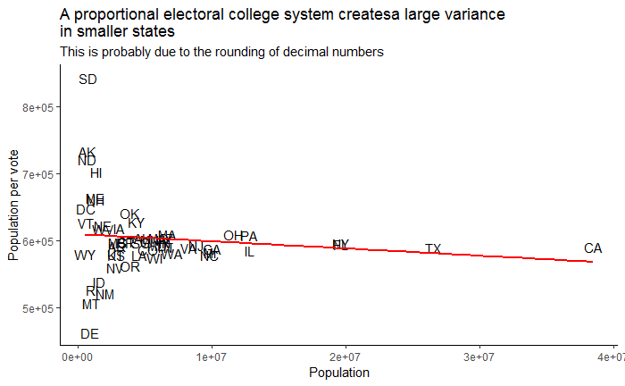